# Viability pipeline

Thiago Loreto Matos

Pharmacogenetics Laboratory, Drug Research and Development Center, Department of Physiology and Pharmacology, Federal University of Ceará, Fortaleza, 60430-160, Brazil

thiago-loreto@hotmail.com

2026-09-05

#### Package

dosefitr 1.0.0

# 1 Introduction

This vignette walks through the **viability / proliferation** dose-response pipeline of `dosefitr`, end-to-end, on bundled example data. The pipeline is single-channel (CellTiter-Glo-style luminescence), in contrast to the dual-channel NanoBRET pipeline covered in `vignette("dosefitr-nanobret", package = "dosefitr")`. The plate layout is the same – this matters because the two pipelines compose: one set of compounds, one set of plate maps, two readouts.

For the package’s motivation for inclusion in Bioconductor and a comparison with other CRAN and Bioconductor dose-response packages, see `vignette("dosefitr", package = "dosefitr")`. For a topic-by-topic NanoBRET walkthrough written as an adaptable analysis template, see `vignette("dosefitr-protocol", package = "dosefitr")`.

The seven stages of the pipeline:

1. Setup and stage the bundled plates into a working directory.
2. Inspect the plate layout and the info table.
3. Process the raw counts into viability tables (`batch_viability_analysis()`).
4. Fit 4PL dose-response curves (`batch_drc_analysis()` with `normalize = TRUE`).
5. Visualise individual and overlay plots (`batch_save_all_drc_plots()`, `plot_multiple_compounds()`, `compare_plates_drc()`).
6. Export the results. `batch_viability_analysis()` and `batch_drc_analysis()` already write result workbooks and a consolidated report when `generate_reports = TRUE` (this vignette sets `FALSE` to keep the knit clean). Optionally, labs that submit to the SGC Scarab system emit a Scarab-format table with `scarab_viability()`.
7. Read the quality metrics.

# 2 Setup

```r
library(dosefitr)
```

The package ships with two viability plates and a single info table covering them both. They are located in `inst/extdata/` and are loaded with `system.file()`:

```r
extdata_dir <- system.file("extdata", package = "dosefitr")

list.files(extdata_dir, pattern = "^viability_")
```

```
#> [1] "viability_info.xlsx"     "viability_plate_01.xlsx"
#> [3] "viability_plate_02.xlsx"
```

`batch_viability_analysis()` scans a directory for plate files matching a regular expression, so we stage the relevant files into a working directory under `tempdir()`. This keeps the vignette compliant with the “no writes outside `tempdir()`” policy:

```r
work_dir <- file.path(tempdir(), "dosefitr_viability")
dir.create(work_dir, showWarnings = FALSE)

invisible(file.copy(
  from      = list.files(extdata_dir, pattern = "^viability_",
                         full.names = TRUE),
  to        = work_dir,
  overwrite = TRUE
))

list.files(work_dir)
```

```
#> [1] "viability_info.xlsx"     "viability_plate_01.xlsx"
#> [3] "viability_plate_02.xlsx"
```

# 3 Plate layout and info table

Each plate is a 384-well PHERAstar luminescence export with a single emission channel. The first 12 rows of the worksheet are instrument metadata; the data block follows at row 13. Each of the 16 rows (`A`-`P`) holds one compound.

The example plates bundled with the package follow the layout below, but this is only an illustration: `dosefitr` does not require the controls in any specific columns. What matters is that you tell the package **where** the controls are with the `control_0perc` and `control_100perc` arguments to `batch_viability_analysis()`. Any column indices in `selected_columns` are allowed – for example, controls in columns 1 and 2 with the dose series across columns 3-24, or interleaved controls at columns 1, 12, and 24. Note that `batch_viability_analysis()` accepts **integer** control column indices, unlike the NanoBRET pipeline which uses character indices. The example layout is:

- **Column 1** – DMSO (vehicle) control, the “100 % viability” baseline.
- **Columns 2-12** – 11 inhibitor concentrations, technical replicate 1.
- **Columns 13-23** – the same 11 concentrations, technical replicate 2.
- **Column 24** – compound-saturated wells, the “0 % viability” floor.

If your plates use a different layout, keep the info table structure the same (log10-concentrations in column 1, one compound per remaining column, `NA` in control rows) and change the `control_0perc` / `control_100perc` / `selected_columns` arguments to match.

`viability_info.xlsx` carries one sheet per plate. The first column holds log10-concentrations (with `NA` for the control rows), the remaining columns identify each plate row:

```r
info_path <- file.path(work_dir, "viability_info.xlsx")

info_plate_01 <- openxlsx::read.xlsx(info_path, sheet = "plate_01")

head(info_plate_01, 8)
```

```
#>   log(inhibitor).[M] Plate_Row  Target Compound
#> 1                 NA         A KinaseA     Cpd1
#> 2              -4.61         B KinaseA     Cpd2
#> 3              -5.13         C KinaseA     Cpd3
#> 4              -5.61         D KinaseA     Cpd4
#> 5              -6.13         E KinaseA     Cpd5
#> 6              -6.61         F KinaseA     Cpd6
#> 7              -7.13         G KinaseA     Cpd7
#> 8              -7.61         H KinaseB     Cpd8
```

The example data covers 16 compounds per plate. Plate 01 mixes three constructs (`KinaseA`, `KinaseB`, `KinaseC`); plate 02 carries one construct (`KinaseD`) plus four bridging rows that repeat plate 01 compounds to demonstrate the inter-plate consistency QC.

# 4 Viability table processing

`batch_viability_analysis()` reads both plates, processes each row against its DMSO control, applies the 0 % floor at the saturated-compound control, and produces viability tables ready for fitting. For the bundled v1-format data we use `version = "v1"`:

```r
via_out <- file.path(tempdir(), "dosefitr_viability_proc")
dir.create(via_out, showWarnings = FALSE)

via_res <- batch_viability_analysis(
  directory        = work_dir,
  info_file        = "viability_info.xlsx",
  data_pattern     = "viability_plate_\\d+\\.xlsx$",
  control_0perc    = 1,
  control_100perc  = 24,
  selected_columns = 1:24,
  generate_reports = FALSE,
  output_dir       = via_out,
  verbose          = FALSE,
  version          = "v1"
)

names(via_res)
```

```
#> [1] "plate_01" "plate_02"
```

Note that viability accepts **integer** control column indices, unlike NanoBRET which uses character indices.

The returned object mirrors the NanoBRET pipeline: one entry per plate, with the processed table under `$result$modified_ratio_table`:

```r
mrt <- via_res$plate_01$result$modified_ratio_table

dim(mrt)
```

```
#> [1] 13 33
```

```r
head(mrt[, 1:6], 8)
```

```
#>   log(inhibitor).[M] KinaseA:Cpd1 KinaseA:Cpd1.2 KinaseA:Cpd2 KinaseA:Cpd2.2
#> 1                 NA       109523         109523       109523         109523
#> 2              -4.61         9898          10224         8975           9129
#> 3              -5.13        11926          14603        12507          12219
#> 4              -5.61        21316          22047        16885          17047
#> 5              -6.13        40063          44125        32561          31923
#> 6              -6.61        68324          61450        56258          55290
#> 7              -7.13        85502          82331        76288          91324
#> 8              -7.61        96138         103499       100161          96542
#>   KinaseA:Cpd3
#> 1       109523
#> 2         8738
#> 3        11422
#> 4        14171
#> 5        25837
#> 6        47060
#> 7        71995
#> 8        96399
```

A well-behaved cytotoxicity curve runs from high signal at the lowest concentrations (cells healthy) down to low signal at the highest concentrations (cells killed):

```r
data.frame(
  log_conc  = mrt[, 1],
  Cpd1_rep1 = round(mrt[, "KinaseA:Cpd1"],   0),
  Cpd1_rep2 = round(mrt[, "KinaseA:Cpd1.2"], 0)
)
```

```
#>    log_conc Cpd1_rep1 Cpd1_rep2
#> 1        NA    109523    109523
#> 2     -4.61      9898     10224
#> 3     -5.13     11926     14603
#> 4     -5.61     21316     22047
#> 5     -6.13     40063     44125
#> 6     -6.61     68324     61450
#> 7     -7.13     85502     82331
#> 8     -7.61     96138    103499
#> 9     -8.00     97221    105311
#> 10    -8.43    109801    108687
#> 11    -8.91    118247    117856
#> 12    -9.38    106328    114284
#> 13       NA      7940      7940
```

The first and last rows (with `NA` log-concentration) carry the 0 % and 100 % control row averages.

# 5 Dose-response curve fitting

`batch_drc_analysis()` fits each compound with a 4PL model. For viability data the standard call passes `normalize = TRUE`, which rescales the raw counts to percent and clamps the fits to viability- plausible Bottom and Top windows.

```r
drc_out <- file.path(tempdir(), "dosefitr_viability_drc")
dir.create(drc_out, showWarnings = FALSE)

drc_res <- batch_drc_analysis(
  batch_results    = via_res,
  model            = "4pl",
  normalize        = TRUE,
  output_dir       = drc_out,
  generate_reports = FALSE,
  verbose          = FALSE
)

drc_res$drc_results$plate_01$drc_result$successful_fits
```

```
#> [1] 16
```

The per-plate summary table reports each compound’s fitted Bottom and Top (in percent), LogIC50/LogEC50, Hill slope, R^2, and a quality label:

```r
sum_01 <- drc_res$drc_results$plate_01$drc_result$summary_table

sum_01[, c("Compound", "LogIC50/LogEC50", "HillSlope",
           "R_squared", "Curve_Quality")]
```

```
#>         Compound LogIC50/LogEC50 HillSlope R_squared         Curve_Quality
#> 1   KinaseA:Cpd1          -6.525     0.727     0.992            Good curve
#> 2   KinaseA:Cpd2          -6.686     0.896     0.992            Good curve
#> 3   KinaseA:Cpd3          -6.906     0.856     0.995            Good curve
#> 4   KinaseA:Cpd4          -7.019     0.973     0.992            Good curve
#> 5   KinaseA:Cpd5          -7.133     1.205     0.992            Good curve
#> 6   KinaseA:Cpd6          -7.283     1.253     0.994            Good curve
#> 7   KinaseA:Cpd7          -7.518     1.264     0.994            Good curve
#> 8   KinaseB:Cpd8          -6.811     0.886     0.997            Good curve
#> 9   KinaseB:Cpd9          -7.033     1.031     0.996            Good curve
#> 10 KinaseB:Cpd10          -7.309     1.154     0.996            Good curve
#> 11 KinaseB:Cpd11          -7.534     1.221     0.998            Good curve
#> 12 KinaseB:Cpd12          -7.761     1.351     0.994            Good curve
#> 13 KinaseB:Cpd13          -8.026     1.277     0.997            Good curve
#> 14 KinaseC:Cpd14          -5.713     0.654     0.986 Wide logIC50 CI range
#> 15 KinaseC:Cpd15          -6.173     0.927     0.993            Good curve
#> 16 KinaseC:Cpd16          -6.465     1.189     0.988            Good curve
```

For this clean bundled data, most compounds earn a `Good curve` label:

```r
table(sum_01$Curve_Quality)
```

```
#>
#>            Good curve Wide logIC50 CI range
#>                    15                     1
```

# 6 Visualisation

## 6.1 Save one plot per compound (and a combined panel per plate)

`batch_save_all_drc_plots()` is the workhorse plotting function for a batch result. It calls `plot_dose_response()` on every successful fit, writes one PNG per compound, and assembles the per-plate compounds into a single panel image with **patchwork**:

```r
plots_dir <- file.path(tempdir(), "dosefitr_viability_plots")
dir.create(plots_dir, showWarnings = FALSE)

results2 <- batch_save_all_drc_plots(
  batch_drc_results    = drc_res,
  output_dir           = plots_dir,
  verbose              = FALSE,
  dpi                  = 120,          # lighter for the vignette
  panel_width_per_col  = 4,
  panel_height_per_row = 4,
  panel_spacing        = 1.2
)

results2$successes
```

```
#> [1] 32
```

```r
basename(results2$panel_files)
```

```
#> [1] "plate_01_panel.png" "plate_02_panel.png"
```

Each plate gets its own subfolder under `output_dir` with the individual compound PNGs and a single `<plate>_panel.png` overview. Here is the assembled panel for plate 01:

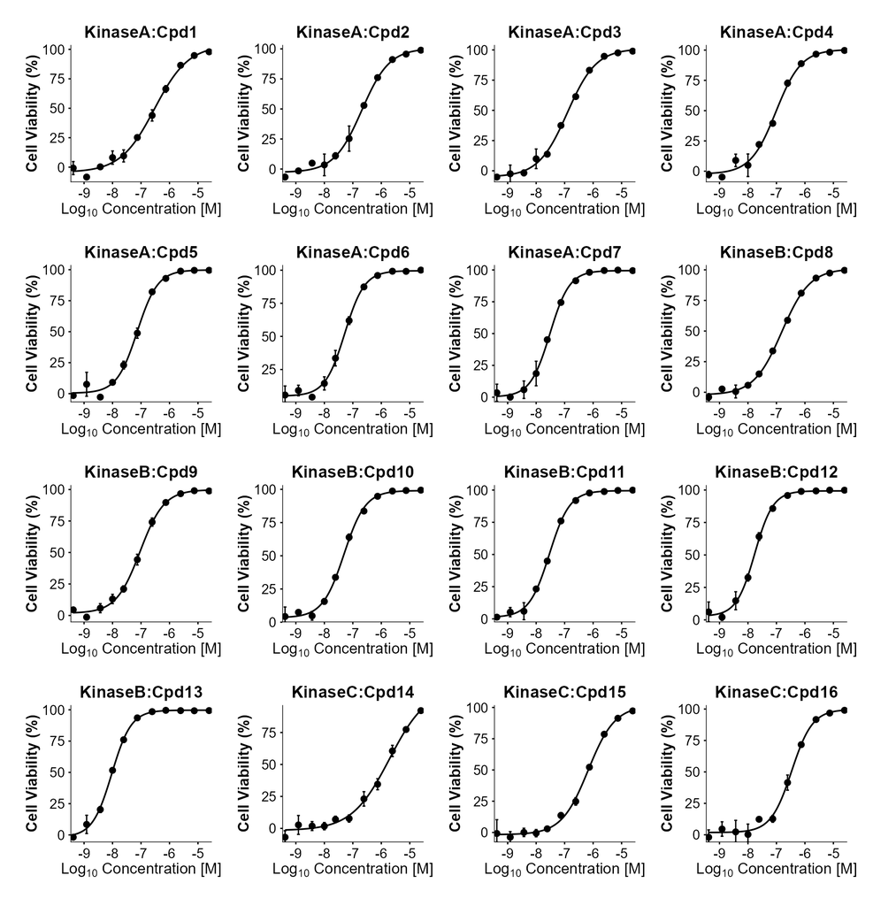

## 6.2 Multiple compounds overlaid

`plot_multiple_compounds()` is the canonical way to compare several compounds in one figure, ranked by potency:

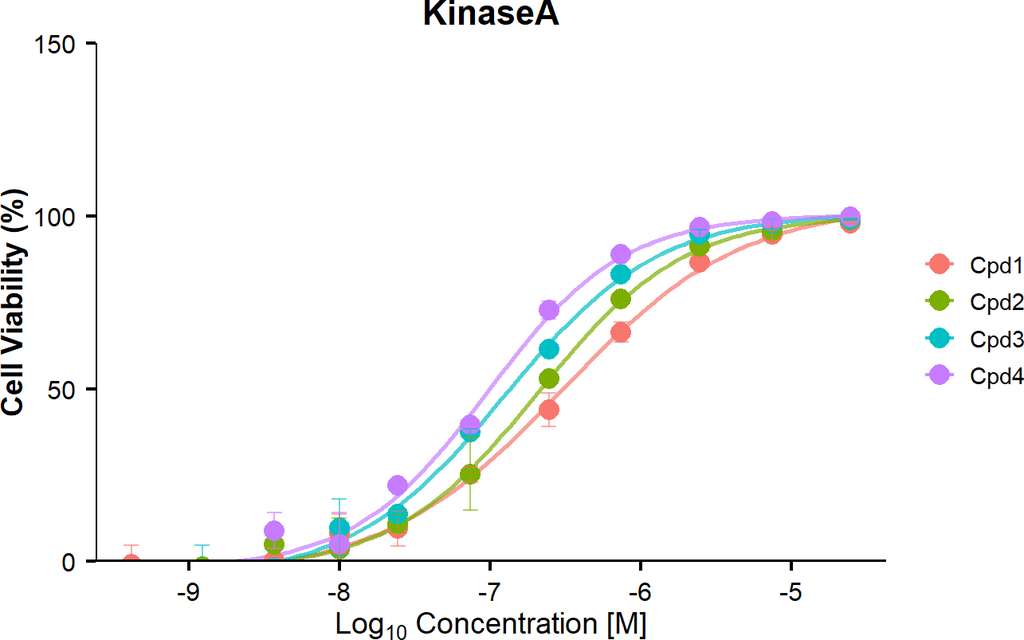

[figure not shown]

```r
plot_multiple_compounds(
  results          = drc_res,
  compound_indices = 1:4,
  plate            = "plate_01",
  show_error_bars  = TRUE,
  verbose          = FALSE
)
```

## 6.3 The same compound across plates

`compare_plates_drc()` makes one figure per construct-compound pair that appears on more than one plate – the inter-plate consistency check. The bundled `plate_02` repeats four of `plate_01`’s compounds under the same construct, so four cross-plate plots are produced:

```r
compare_out <- file.path(tempdir(), "dosefitr_viability_compare")
dir.create(compare_out, showWarnings = FALSE)

cmp_res <- compare_plates_drc(
  batch_drc_result = drc_res,
  compare_by       = "construct_compound",
  output_dir       = compare_out,
  min_plates       = 2,
  verbose          = FALSE
)

list.files(compare_out, pattern = "\\.png$")
```

```
#> [1] "KinaseA__Cpd1.png"  "KinaseA__Cpd5.png"  "KinaseB__Cpd13.png"
#> [4] "KinaseB__Cpd9.png"
```

The returned object’s `$plots` list has one ggplot per pairing.

# 7 Export

The main results are already exported by the batch functions: with `generate_reports = TRUE` (the default), `batch_viability_analysis()` writes per-plate result workbooks plus quality-metric files, and `batch_drc_analysis()` writes the fitted `drc_results` and its own consolidated report. The Scarab table below is an **optional, lab-specific** step for groups that submit to the SGC Scarab system; skip it if you do not.

## 7.1 Scarab-format submission table (optional, lab-specific)

`scarab_viability()` produces a wide submission table in the SGC Scarab format for viability assays:

```r
sc_01 <- scarab_viability(
  results_list        = via_res,
  drc_results_list    = drc_res,
  plate_name          = "plate_01",
  date                = format(Sys.Date(), "%y%m%d"),
  experimenter_abbrev = "DEMO",
  save                = FALSE
)

dim(sc_01)
```

```
#> [1] 67 17
```

```r
head(sc_01[, 1:5], 6)
```

```
#>                            Field                       X4
#> 1                      Cell line                     HeLa
#> 2                      Cell Type  cervical adenocarcinoma
#> 3                 Treatment Time                      72h
#> 4                       Compound                     Cpd1
#> 5                  Experiment ID 260905-DEMO-KinaseA-Cpd1
#> 6 SGC Global Compound ID (Batch)                     <NA>
#>                         X5                       X6                       X7
#> 1                     HeLa                     HeLa                     HeLa
#> 2  cervical adenocarcinoma  cervical adenocarcinoma  cervical adenocarcinoma
#> 3                      72h                      72h                      72h
#> 4                     Cpd2                     Cpd3                     Cpd4
#> 5 260905-DEMO-KinaseA-Cpd2 260905-DEMO-KinaseA-Cpd3 260905-DEMO-KinaseA-Cpd4
#> 6                     <NA>                     <NA>                     <NA>
```

# 8 Reading the quality metrics

The output of `batch_viability_analysis()` includes per-plate quality metrics, printed at run time when `verbose = TRUE`. Key numbers:

- **S/B** – ratio of mean 100 % control wells (DMSO) to mean 0 % control wells (compound-saturated). Above 5 is usable.
- **Z-prime** – robustness statistic combining S/B with control variability. Above 0.5 is usable, above 0.7 is excellent.
- **CV %** – coefficient of variation between technical replicates. Under 10 % is well-behaved.

The fit-level `Curve_Quality` column carries one of:

- `Good curve` – everything passed.
- `Wide LogIC50/LogEC50 CI range` – the IC50 95 % CI is wider than the test concentration range; the IC50 is at or beyond a tested concentration.
- `Top too low` / `Bottom too high` – the fitted plateaux do not bracket the response range.

See `?batch_drc_analysis` for the complete list and thresholds.

# 9 Other layouts: the v2 and v3 processors

`batch_viability_analysis()` supports three layouts via the `version` argument. The `version = "v1"` processor used above expects two technical replicates per plate row. The other two handle different control and replicate conventions:

- **`version = "v2"` (NanoBRET-style).** The 0 % control is a *fixed scalar* supplied through `control_0perc` (never a plate well); it becomes a constant `Fixed_0perc` first row. The 100 % control is one or more *plate columns* named in `control_100perc`, averaged into a single `Mean_100perc` last row and then consumed. This mirrors the control style of `ratio_dose_response_v2()` on the NanoBRET side.
- **`version = "v3"` (row-based replicates).** One replicate per plate row; replicate rows are encoded as repeated `Target` + `Compound` pairs in the info table, and the output column names receive `.2`, `.3`, … suffixes.

```r
# v2: fixed 0 % scalar + one or more averaged 100 % columns
via_res_v2 <- batch_viability_analysis(
  directory        = work_dir,
  info_file        = "viability_info.xlsx",
  data_pattern     = "viability_plate_\\d+\\.xlsx$",
  control_0perc    = 1,           # fixed scalar baseline (not a column)
  control_100perc  = 24,          # 100 % control column(s); may be a vector
  selected_columns = 1:24,
  generate_reports = FALSE,
  output_dir       = via_out,
  version          = "v2"
)
```

All three processors share the downstream pipeline: the same `batch_drc_analysis()` call, the same plot functions, and the same `scarab_viability()` export. They differ only in how the 0 % / 100 % controls and replicates are laid out; see `?process_viability_data_v2` and `?process_viability_data_v3` for the full contracts.

# 10 See also

- `vignette("dosefitr", package = "dosefitr")` – introduction, motivation, and comparison with related packages.
- `vignette("dosefitr-nanobret", package = "dosefitr")` – the BRET-ratio pipeline using the same plate layout.
- `?batch_viability_analysis`, `?batch_drc_analysis`, `?scarab_viability` – parameter-level documentation.